# Investigating Politics

March 28, 2018

## From Correlation to Causality

### A summary

## The Problem

## What is the problem?

### Correlation as clue to Causality

If \(X \rightarrow Y\):

- Values of \(X\) and \(Y\) should move together
- Values of \(X\) and \(Y\) should be correlated
- This correlation should not be **by chance**

### A hiccup:

It is possible that \(X,Y\) are correlated, without causation

## What is the problem?

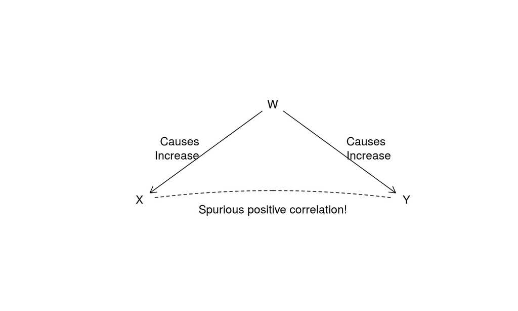

## Spurious Correlation:

**spurious correlation**: when the **observed** correlation between \(X\) (independent variable) and \(Y\) (dependent variable) inaccurately reflects the **true** causal relationship \(X \rightarrow Y\)

- Can think of this as a kind of **bias**:

\[Correlation_{True}(X,Y) - Correlation_{Observed}(X,Y) \neq 0\]

## Spurious Correlation:

**confounding variables** are the **source** of **spurious correlation**:

- Variables other than \(X,Y\) (e.g. \(W\)), that are related to both \(X\) and \(Y\)

## Spurious Correlation:

### Types:

1. **confounding variables** cause both \(X,Y\) to appear correlated when \(X\) **does not cause** \(Y\)

## Spurious Correlation: Truth

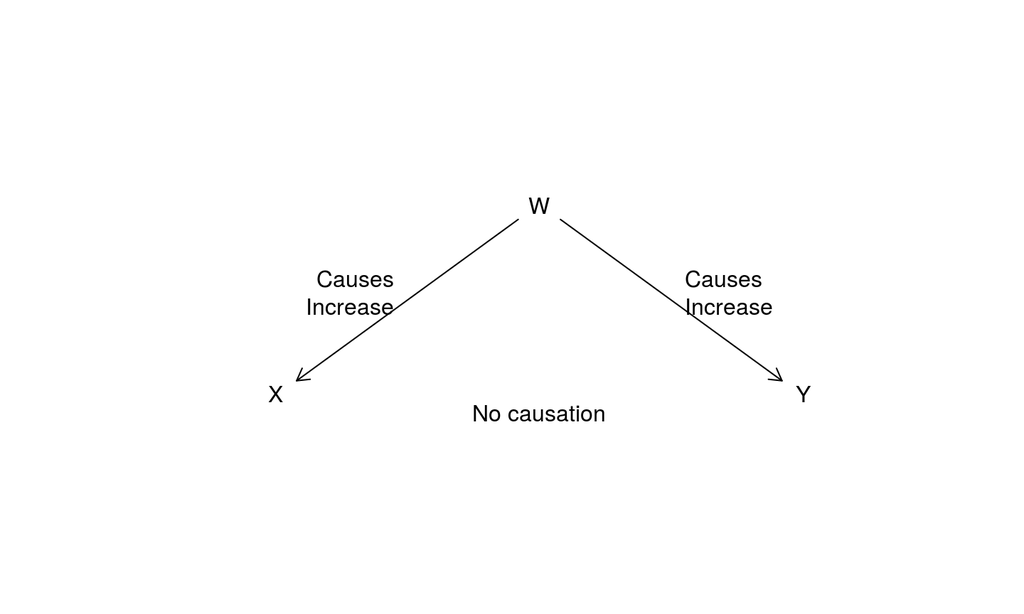

## Spurious Correlation: Observed

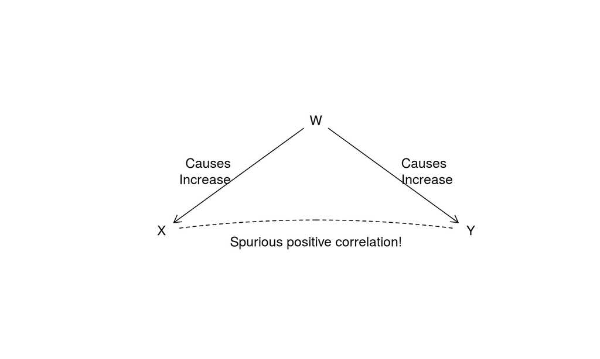

## Spurious Correlation:

### Types:

1. **confounding variables** cause both \(X,Y\) to appear correlated when \(X\) **does not cause** \(Y\)
2. **confounding variables** cause both \(X,Y\) to appear **uncorrelated** when \(X\) **does cause** \(Y\)

## Spurious Correlation: Truth

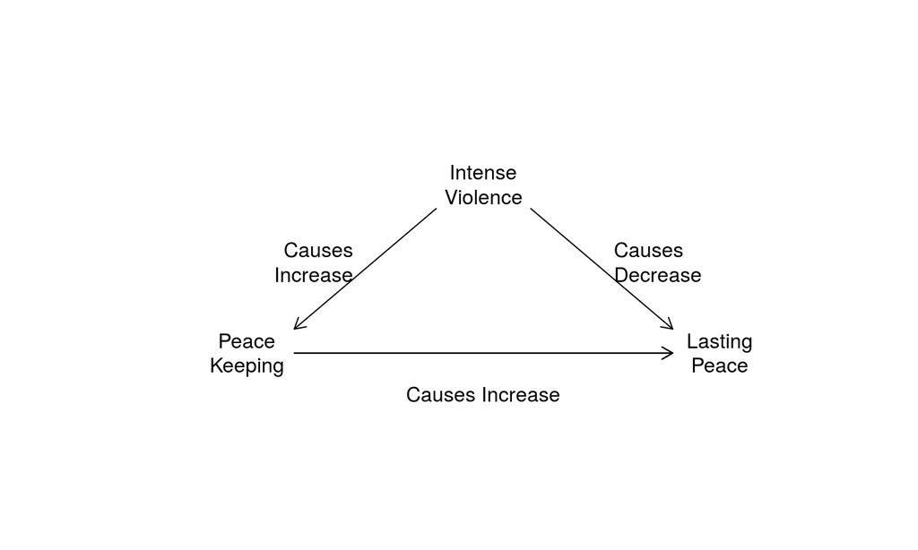

## Spurious Correlation: Observed

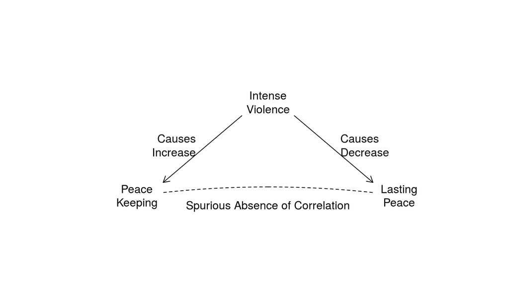

## Spurious Correlation:

### Types:

1. **confounding variables** cause \(X,Y\) to appear correlated when \(X\) **does not cause** \(Y\)
2. **confounding variables** cause \(X,Y\) to appear **uncorrelated** when \(X\) **does cause** \(Y\)
3. **confounding variables** cause \(X,Y\) relationship to be **too positive** or **too negative**
   - effect of \(X \rightarrow Y\) appears **too strong** compared to **truth**
   - effect of \(X \rightarrow Y\) appears **too weak** compared to **truth**
   - effect of \(X \rightarrow Y\) appears **wrong direction** compared to **truth**

## Spurious Correlation: Truth

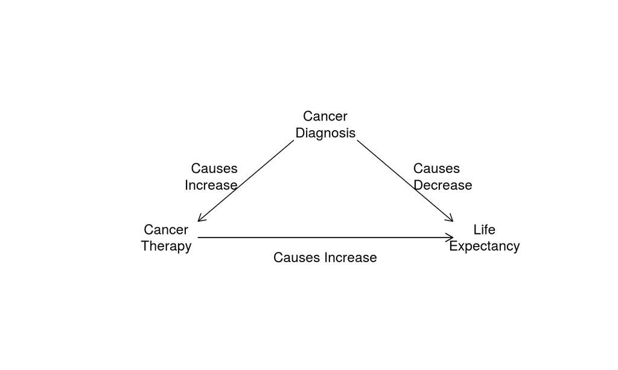

## Spurious Correlation: Observed

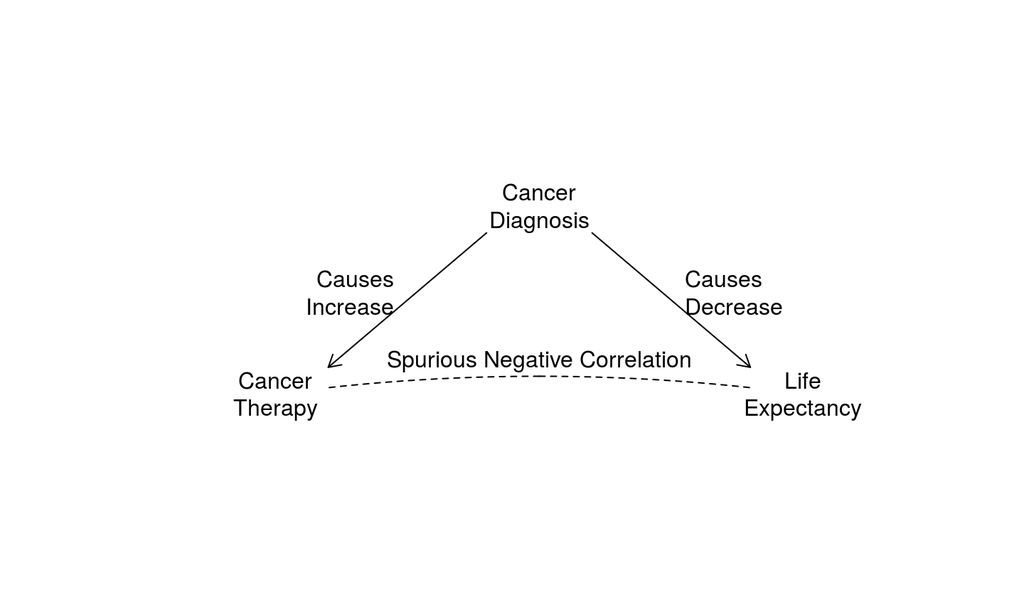

## Spurious Correlation:

### Types:

1. **confounding variables** cause \(X,Y\) to appear correlated when \(X\) **does not cause** \(Y\)
2. **confounding variables** cause \(X,Y\) to appear **uncorrelated** when \(X\) **does cause** \(Y\)
3. **confounding variables** cause \(X,Y\) relationship to be **too positive** or **too negative**
   - effect of \(X \rightarrow Y\) appears **too strong** compared to **truth**
   - effect of \(X \rightarrow Y\) appears **too weak** compared to **truth**
   - effect of \(X \rightarrow Y\) appears **wrong direction** compared to **truth**

## Spurious Correlation:

### Bias

All of these are examples of **bias**: true causal relationship of \(X,Y\) not observed due to **confounding**

- **bias** implies absence of **internal validity** (recovering **true** causal relationship)

## Spurious Correlation:

### What you need to know:

1. What is spurious correlation/bias?
2. Why does it happen?
3. What is confounding?
4. What are the different forms it can take?
5. If we know **direction** of effects of \(W\) on both \(X,Y\), what is direction of **bias**/**spurious** relationship

## Solutions for Confounding

## What we need to know:

1. What are broad types of solutions?
   - Adjustment vs Design (Similar Cases, Same Case, Diff-in-Diff, Natural Experiments, Experiments)
2. For each broad type:
   - **How** does it remove confounding
   - **What confounding** does it eliminate/not eliminate
   - **What** are its key **assumptions** (to conclude **no remaining bias**/spurious correlation)
   - **What** is the **tradeoff** between **internal** and **external** validity

## Adjustment

- **How it fixes confounding**:
  - Holds confounding variables constant, can no longer induce spurious correlation
  - **conditioning** looks at correlation of \(X,Y\) holding **confounding variables** constant

## Adjustment: No Conditioning

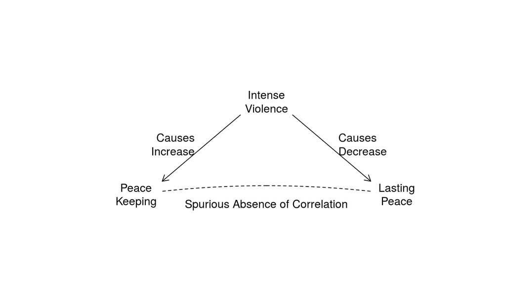

## Adjustment: With Conditioning

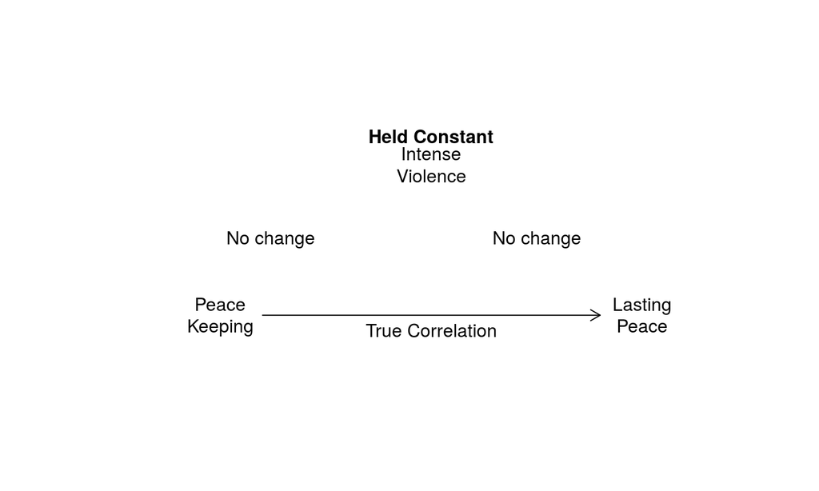

## Adjustment

- **How it fixes confounding**:
  - Holds confounding variables constant, can no longer induce spurious correlation
  - **conditioning** looks at correlation of \(X,Y\) holding **confounding variables** constant
- **What confounding is removed**:
  - Removes confounding from **all measured variables** used in **conditioning**
  - **Does not** remove confounding from **unmeasured**/**mis-measured** variables

## Adjustment: No Conditioning

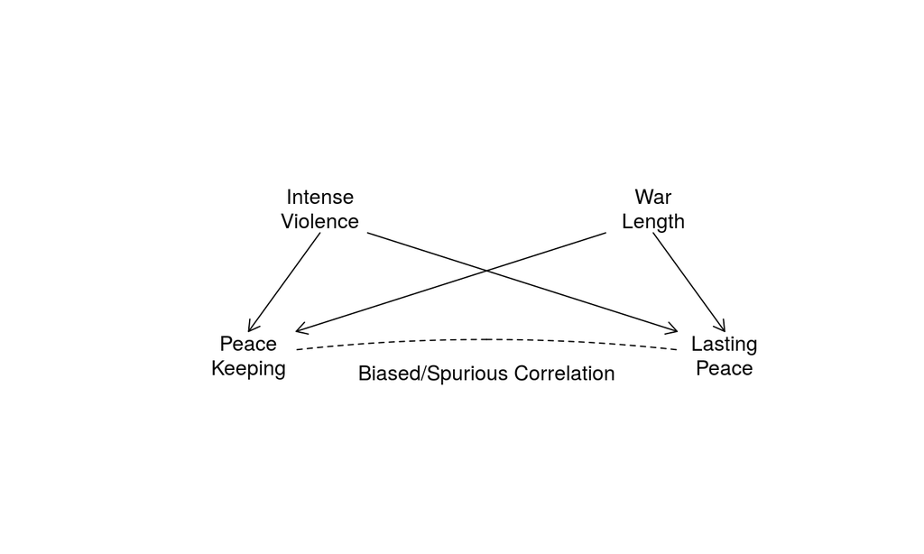

[figure not shown]

## Adjustment

- **How it fixes confounding**:
  - Holds confounding variables constant, can no longer induce spurious correlation
  - **conditioning** looks at correlation of \(X,Y\) holding **confounding variables** constant
- **What confounding is removed**:
  - Removes confounding from **all measured variables** used in **conditioning**
  - Does not remove confounding from **unmeasured**/**mis-measured** variables

## Adjustment

- **Key Assumptions** (to conclude no remaining bias):
  - Condition on **all** confounding variables
  - No measurement error on confounding variables
- **Methods**:
  - Matching (compare cases with same values on confounding variables)
  - Regression (linear approximation of above)
- **Tradeoff**
  - Can be done for **all relevant** cases, **high external validity**
  - Requires big assumptions, **low internal validity**

## Design:

**design**-based solutions:

Choose comparison so that we eliminate possible **confounding** variables

- Hold **confounding** variable **constant** (like conditioning)

#### **OR**

- Break link between confounding variable(s) \(W\) and independent variable \(X\)

## Design: Similar Cases

Compare cases in same **place** and **time**

- **How it fixes confounding**:
  - Holds confounding variables **constant**, can no longer induce spurious correlation
- **What confounding is removed**:
  - Removes confounding from **all measured/unmeasured variables** that are **the same** for compared cases
  - Does not account for **unchanging** variables that **differ** between cases
  - Does not account for **changing** variables that **differ** between cases

## Design: Similar Cases

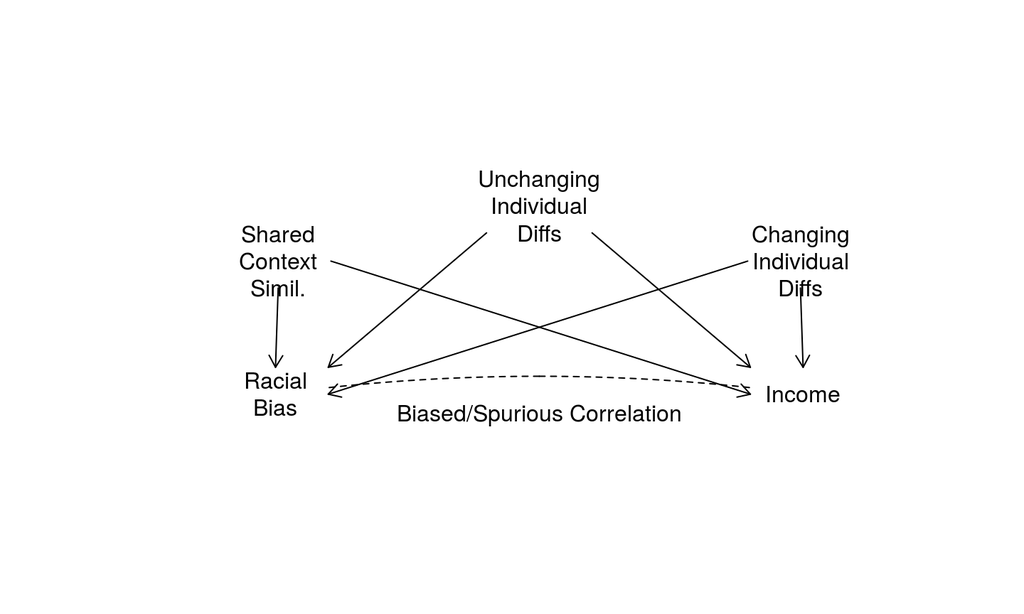

## Design: Similar Cases

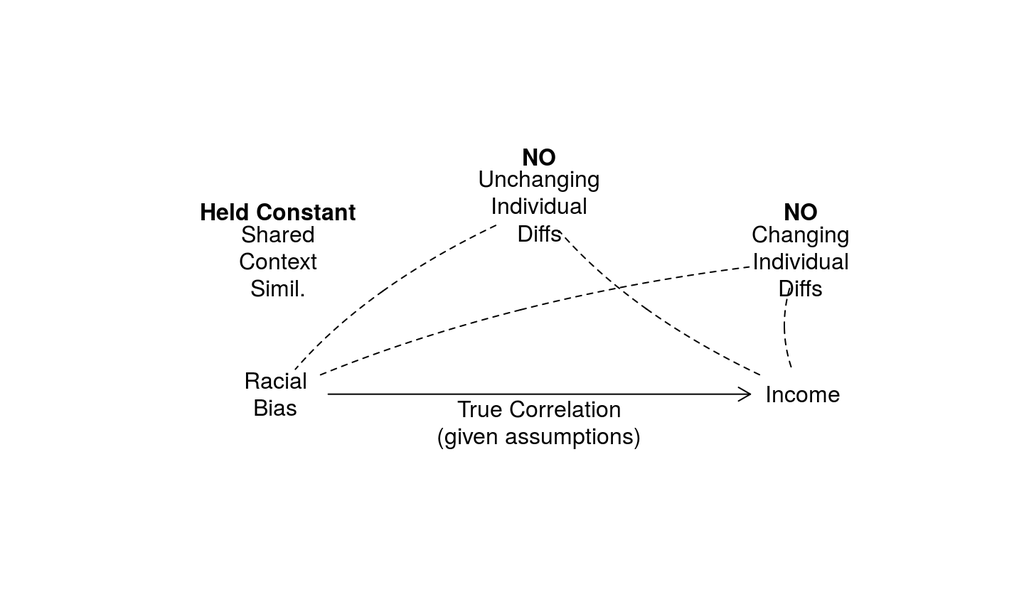

## Design: Similar Cases

Compare cases in same **place** and **time** with different exposure to the cause

- **How it fixes confounding**:
  - Holds confounding variables **constant**, can no longer induce spurious correlation
- **What confounding is removed**:
  - Removes confounding from **all measured/unmeasured variables** that are **the same** for compared cases
  - Does not account for **unchanging** variables that **differ** between cases (e.g. different housing quality)
  - Does not account for **changing** variables that **differ** between cases (e.g. location of **new** schools)

## Design: Similar Cases

- **Key Assumptions** (to conclude no remaining bias):
  - No **constant**/**time-invariant** differences between cases that affect \(X,Y\)
  - No **changing**/**time-variant** differences between cases that affect \(X,Y\)
- **Methods**:
  - Finding cases close in time and space
- **Tradeoff**
  - **Very similar cases** with different \(X\) not possible for all relevant cases, **lower external validity**
  - Requires fewer assumptions about confounding variables, **higher internal validity**

## Design: Same Case

Compare same case to itself over time

- **How it fixes confounding**:
  - Holds confounding variables **constant**, can no longer induce spurious correlation
- **What confounding is removed**:
  - Removes confounding from **all measured/unmeasured variables** that are **unchanging** for the case
  - Does not remove confounding variables that **change** over time

## Design: Same Case

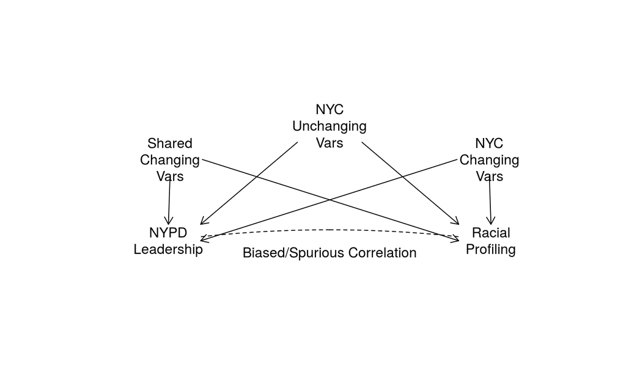

## Design: Same Case

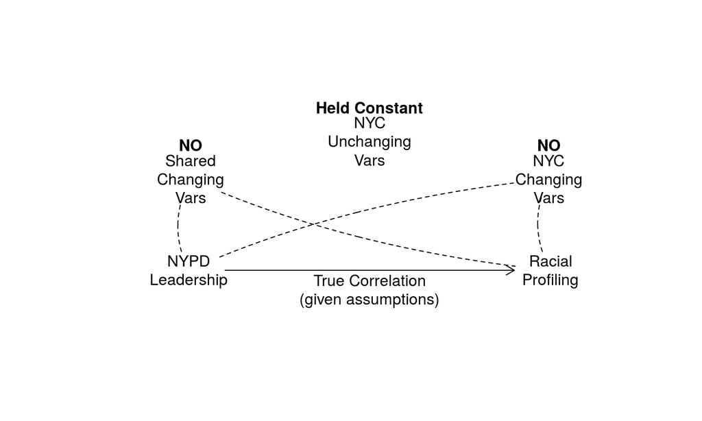

## Design: Same Case

Compare same case to itself over time

- **How it fixes confounding**:
  - Holds confounding variables **constant**, can no longer induce spurious correlation
- **What confounding is removed**:
  - Removes confounding from **all measured/unmeasured variables** that are **unchanging** for the case
  - Does not remove confounding variables that **change** over time

## Design: Same Case

- **Key Assumptions** (to conclude no remaining bias):
  - No confounding variables that **change over time** for *this* case (e.g. Terrorist bombing in NYC)
  - No confounding variables that **change over time** for *all* cases (e.g. #BlackLivesMatter)
- **Methods**:
  - "interrupted time series"
- **Tradeoff**
  - Result for individual case may not to all relevant cases, **lower external validity**
  - Requires fewer assumptions about confounding variables, **higher internal validity**

## Design: Diff-in-Diff

Compare same case to itself over time against another case to itself

- **How it fixes confounding**:
  - Holds confounding variables **constant**, can no longer induce spurious correlation
- **What confounding is removed**:
  - Removes confounding from **all measured/unmeasured variables** that are
    - **unchanging** for each case
    - **changing** over time and shared by **all cases** (shared trend)
  - Does not remove confounding variables that **change** over time but **differ** across cases (case-specific trend)

## Design: Diff-in-Diff

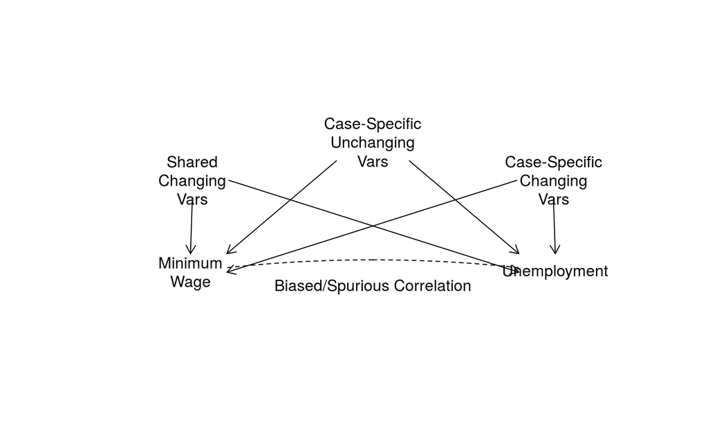

## Design: Diff-in-Diff

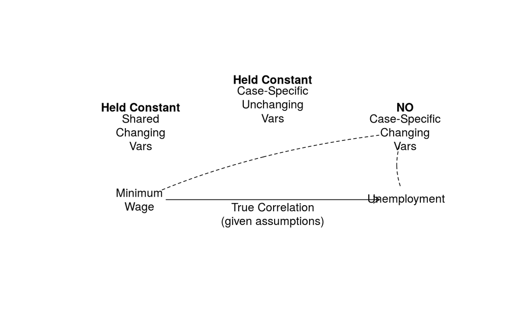

## Design: Diff-in-Diff

Compare same case to itself over time against another case to itself

- **How it fixes confounding**:
  - Holds confounding variables **constant**, can no longer induce spurious correlation
- **What confounding is removed**:
  - Removes confounding from **all measured/unmeasured variables** that are
    - **unchanging** for each case (e.g. history of NJ, PA)
    - **changing** over time and shared by **all cases** (shared trends; e.g. changing national/regional economy)
  - Does not remove confounding variables that **change** over time but **differ** across cases (case-specific trends; e.g. PA /NJ have different voting trends)

## Design: Diff-in-Diff

- **Key Assumptions** (to conclude no remaining bias):
  - No confounding variables that change over time **differently** across cases (no differences in trends)
  - Conversely: assume trends are parallel (the same) across cases in absence of the cause (counterfactually)
- **Methods**:
  - check pre-cause parallel trends
  - "synthetic control" artificially produces (rather than assume) parallel trends
- **Tradeoff**
  - Cases with similar trends, but different "treatments" may be rare, **lower external validity**
  - Requires even fewer assumptions about confounding variables, **higher internal validity**

## Design: Natural Experiments

Compare cases where cause/independent variable/\(X\) is (as-if) randomly assigned by "nature"

- **How it fixes confounding**:
  - Breaks link between confounding variables \(W,Z,\ldots\) and the independent variable \(X\)
- **What confounding is removed**:
  - Removes confounding from **all measured/unmeasured variables**

## Design: Natural Experiments

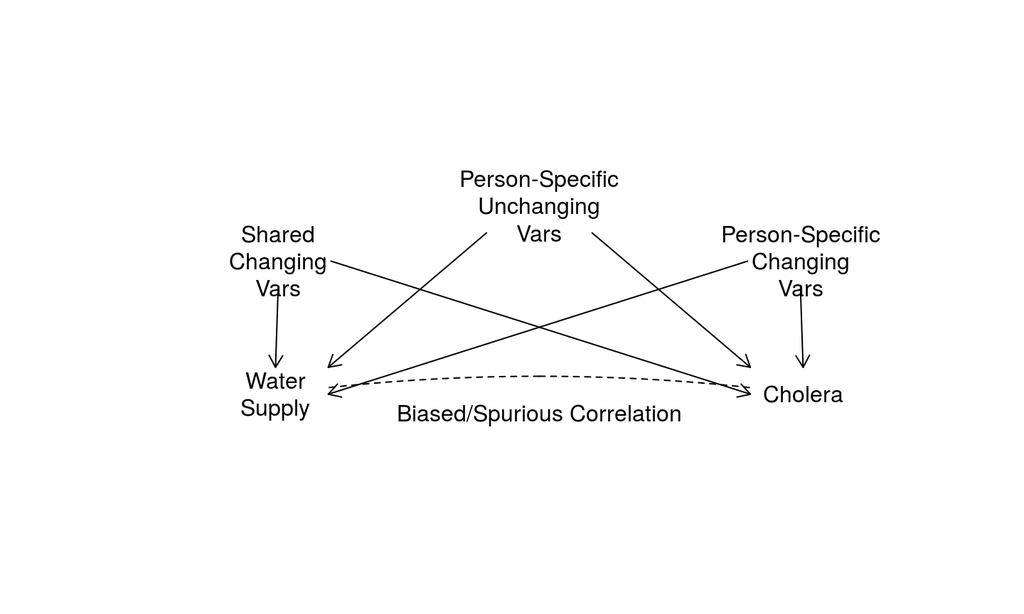

## Design: Natural Experiments

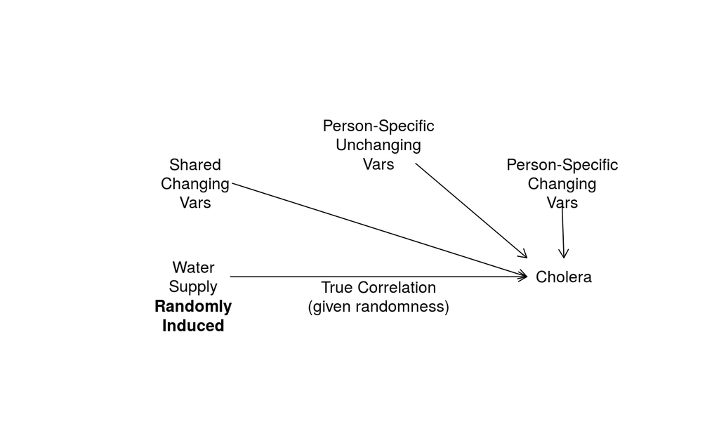

## Design: Natural Experiments

Compare cases where cause/independent variable/\(X\) is (as-if) randomly assigned by "nature"

- **How it fixes confounding**:
  - Breaks link between confounding variables \(W,Z,\ldots\) and the independent variable \(X\)
- **What confounding is removed**:
  - Removes confounding from **all measured/unmeasured variables**

## Design: Natural Experiments

- **Key Assumptions** (to conclude no remaining bias):
  - Cause is random (cases either unmotivated to, unable to, or unaware of selecting "treatment")
- **Methods**:
  - **standard natural experiment**
  - **regression discontinuity**
  - **instrumental variables**
- **Tradeoff**
  - cases with randomized cause unusual/rare; **low external validity**
  - Requires minimal assumptions about confounding variables, **high internal validity**

## Summary:

|  | How Bias Solved | Which Bias Removed | Assumes | Internal Validity | External Validity |
| --- | --- | --- | --- | --- | --- |
| Adjustment | Hold constant | All **measured** confounding variables | Condition all confounders | Lowest | Highest |
| Similar Cases | Hold constant | Cases' **shared** confounding variables | **No** diff. b/t cases | Middle | Middle |
| Same Case | Hold constant | Case's **unchanging** confounding variables | **No** confounding trends | Middle | Middle |
| Diff in Diff | Hold constant | Case's **unchanging** variables Cases' **shared** trends | Cases have parallel trends | Higher | Lower |
| Natural Experiment | Break \(W \rightarrow X\) link | **All** confounding variables | \(X\) as-if random | Highest | Lowest |